# Análisis de regresión lineal múltiple para la participación de mercado de productos de higiene femenina

Elizabeth Marlen Sánchez Jaimes

17/7/2020

# Participación de mercado como poder en el mercado

“Participación de mercado como fuente de poder de mercado: Implicaciones y Evidencias” es un interesante artículo basado en el análisis estadístico de una muestra de 6,492 bancos en los años setenta, para demostrar la premisa en la cual la empresa con una alta participación, controla y tiene el poder de mercado, generando mayores rendimientos. Se hace referencia al liderazgo y la participación de mercado de una industria en particular, y difiere del poder del mercado generado por oligopolios, en donde el número de vendedores es muy reducido de manera que controlan y acaparan las ventas de determinados productos.

Para el estudio de la relación entre la participación, posicionamiento y poder en el mercado, algunos modelos tradicionales eran deficientes en el sentido de que no mencionaban que la empresa con fuerte participación en el mercado, genera altas tasas de retorno a consecuencia de su posicionamiento, y como la empresa que lidera el mercado en términos de participación, mantiene también el liderazgo en precio, y simplemente establece el precio, mientras que las otras industrias, siguen el mismo parámetro indicado por el líder del mercado. Sin embargo, algunas industrias reducen sus precios con la finalidad de incrementar sus ventas y atraer más clientes, lo cual genera respuesta en el líder del mercado quién puede optar por competir en la reducción de sus precios o incluso considerar otras alternativas para evitar competencia induciendo incluso a que el mercado aumente sus precios.

Es importante indicar que las pruebas estadísticas realizadas en el estudio para medir la relación entre el posicionamiento y el poder de mercado enfrentó varias dificultades en la obtención de la base de datos y muestras. Esto derivado de la diversificación de la industria, la diferenciación del producto e incluso sus procesos para la asignación de costos, por lo que este estudio se centró en la información del sector bancario por la consistencia de la información y la extensión de la muestra. Es importante mencionar, además del estudio estadístico, la influencia que tienen los consumidores para determinar desde su perspectiva, la industria con mayor posicionamiento del mercado, quién lidera la inherente diferenciación del producto, y esto le permite al líder del mercado incluso vender sus productos a precios más elevados, aunque conserve la misma calidad de sus competidores. En general, la tendencia del consumidor es seguir y dar gusto al grupo, por lo que es de vital importancia la influencia de los consumidores para elegir el producto y es preocupación de la empresa líder el salvaguardar su reputación en el mercado. Dicho lo anterior, el reconocimiento de la marca por parte del consumidor es vital, pues es en donde se encuentra realmente el valor de la empresa y la competencia simplemente no puede competir con la marca, aunque su producto sea competitivo en calidad con el del líder del mercado.

Para el análisis que nos ocupa, la muestra de 6,492 bancos en existencia entre los años 1969-1978, las medidas de las tasas de retorno indican el poder en el mercado. Se consideran varias variables como la concentración de mercado, su tamaño medido por el promedio total de activos, se incluye una variable dicotómica que distingue los bancos miembros de la Reserva Federal que, por las altas reservas que requerían, impactaban en obtener menores utilidades, entre otras como el periodo promedio anual de los depósitos o préstamos. Como resultado del análisis entre la relación de la participación de mercado y el poder de mercado o las tasas de retorno, se indica que el banco con la más alta participación en el mercado tiene las más altas tasas de retorno. Se realizó un análisis de regresión y la ecuación se utilizó para el total de la muestra ratificando que entre más alta es la participación de mercando más altas son las ganancias, se demostró que los bancos miembros de la reserva federal percibían menos utilidades, pero esto se explicó por los montos en requerimientos de reservas en comparación con los otros bancos que conformaban un holding y no del sistema federal.

El análisis estadístico demostró con base a evidencia empírica que algunas teorías estaban equivocadas como la de Demsetz (1973) la cual argumentaba que las importantes ganancias de las grandes industrias se debían a la eficiencia en lugar del poder de mercado, este estudio demuestra estadísticamente que, a mayor posicionamiento, poder y participación de mercado, el impacto es directamente proporcional a generar altas tasas de retorno.

# Análisis por región

Fueron proporcionados los datos de un productor designado “B” sobre su participación de mercado y sus ventas de productos en diferentes regiones de Centroamérica: seis países y la región comprendida como un total.

Para comenzar el análisis visualizamos un resumen de la base de datos. Notamos que abril tiene una observación adicional por región, porque nuestros datos van desde abril 2017 a abril 2020.

A excepción de la fecha, el país y el mes, todas nuestras variables son numéricas. Por la naturaleza de lo que representan, son variables que sólo toman valores enteros: agotamientos, inventarios, distribución y ventas. No contamos con variables dicotómicas ni categóricas.

El precio promedio es de al rededor de 3.50 dólares en estas regiones y varía un -40% en cuanto al precio mínimo y 48% respecto al precio máximo de 5.2 dólares. El mínimo de su participación de mercado por mes es de casi el 30%, lo que quiere decir que el productor acapara un gran porcentaje del mercado de Centroamérica.

Finalmente, para el resto de las variables, se decidió que se requiere llevar a cabo un análisis para cada país.

```
##      fecha                pais            distribucion    agotamientos
##  Min.   :2017-04-01   Length:259         Min.   : 52.0   Min.   : 0.000
##  1st Qu.:2018-01-01   Class :character   1st Qu.: 61.0   1st Qu.: 4.000
##  Median :2018-10-01   Mode  :character   Median : 76.0   Median : 5.000
##  Mean   :2018-10-01                      Mean   :119.9   Mean   : 7.552
##  3rd Qu.:2019-07-01                      3rd Qu.: 82.0   3rd Qu.: 6.000
##  Max.   :2020-04-01                      Max.   :432.0   Max.   :32.000
##
##      ventas             precio       inventarios       participacion
##  Min.   :  777000   Min.   :2.102   Min.   : 1579300   Min.   :0.2706
##  1st Qu.: 2716650   1st Qu.:2.896   1st Qu.: 2648400   1st Qu.:0.3699
##  Median : 4788000   Median :3.196   Median : 5227200   Median :0.5361
##  Mean   : 7293549   Mean   :3.432   Mean   : 8292449   Mean   :0.5062
##  3rd Qu.: 6837550   3rd Qu.:4.018   3rd Qu.: 9212300   3rd Qu.:0.5866
##  Max.   :29490500   Max.   :5.231   Max.   :32190900   Max.   :0.6719
##
##       mes
##  4      : 28
##  1      : 21
##  2      : 21
##  3      : 21
##  5      : 21
##  6      : 21
##  (Other):126
```

```
## Rows: 259
## Columns: 9
## $ fecha         <date> 2017-04-01, 2017-05-01, 2017-06-01, 2017-07-01, 2017...
## $ pais          <chr> "CAM", "CAM", "CAM", "CAM", "CAM", "CAM", "CAM", "CAM...
## $ distribucion  <dbl> 430, 430, 429, 432, 430, 427, 424, 417, 417, 428, 425...
## $ agotamientos  <dbl> 26, 25, 31, 27, 26, 28, 29, 25, 22, 32, 28, 22, 26, 2...
## $ ventas        <dbl> 29490500, 29419900, 28066400, 27994900, 27462100, 268...
## $ precio        <dbl> 3.213198, 3.240403, 3.229764, 3.255219, 3.262466, 3.3...
## $ inventarios   <dbl> 31090700, 30847700, 29363700, 30051800, 31829100, 321...
## $ participacion <dbl> 0.5393111, 0.5399187, 0.5301619, 0.5323773, 0.5288587...
## $ mes           <fct> 4, 5, 6, 7, 8, 9, 10, 11, 12, 1, 2, 3, 4, 5, 6, 7, 8,...
```

## Propuesta para el total de Centroamérica

### Exploratorio

Al ver la relación que guardan las variables presentadas en los datos recabados para Centroamérica, llama la atención que la relación entre ventas y precio sea débil y positiva (0.31). Dado que lo que se vende está destinado a higiene femenina y que el precio presentado es unitario, una primera inferencia es que al realizar sus compras, las consumidoras no prefieren los productos más baratos, sino que están dispuestas a gastar un poco más. Esta idea se reafirma al ver que la participación de mercado está muy pobremente influenciada por el precio. Sin embargo, también debe tenerse en cuenta que los rangos de precios manejados por el productor B han sido muy estrechos, con una variación de sólo el 10% entre el precio máximo y el mínimo.

Como podemos observar, la participación de mercado se relaciona más con la distribución, ventas e inventarios. Con el nivel de ventas sucede algo similar, por lo que un factor clave para el productor B en Centroamérica es poder estar al alcance de sus consumidoras finales. En general, la participación de mercado está por encima del 50% y varía sólo un 8% entre su nivel mínimo y el máximo.

```
##      fecha                pais            distribucion    agotamientos
##  Min.   :2017-04-01   Length:37          Min.   :399.0   Min.   :13.00
##  1st Qu.:2018-01-01   Class :character   1st Qu.:415.0   1st Qu.:25.00
##  Median :2018-10-01   Mode  :character   Median :417.0   Median :27.00
##  Mean   :2018-10-01                      Mean   :419.5   Mean   :26.43
##  3rd Qu.:2019-07-01                      3rd Qu.:427.0   3rd Qu.:28.00
##  Max.   :2020-04-01                      Max.   :432.0   Max.   :32.00
##
##      ventas             precio       inventarios       participacion
##  Min.   :14853800   Min.   :3.032   Min.   :24529500   Min.   :0.4998
##  1st Qu.:24472400   1st Qu.:3.120   1st Qu.:27806200   1st Qu.:0.5146
##  Median :25710900   Median :3.167   Median :29306100   Median :0.5255
##  Mean   :25527422   Mean   :3.169   Mean   :29023559   Mean   :0.5231
##  3rd Qu.:26836700   3rd Qu.:3.213   3rd Qu.:30702000   3rd Qu.:0.5313
##  Max.   :29490500   Max.   :3.336   Max.   :32190900   Max.   :0.5399
##
##       mes
##  4      : 4
##  1      : 3
##  2      : 3
##  3      : 3
##  5      : 3
##  6      : 3
##  (Other):18
```

```
##               distribucion agotamientos    ventas      precio inventarios
## distribucion     1.0000000   0.38356074 0.7996666  0.48901786   0.7671739
## agotamientos     0.3835607   1.00000000 0.4780252 -0.04051866   0.2032660
## ventas           0.7996666   0.47802524 1.0000000  0.31570273   0.7140734
## precio           0.4890179  -0.04051866 0.3157027  1.00000000   0.4841222
## inventarios      0.7671739   0.20326601 0.7140734  0.48412219   1.0000000
## participacion    0.8107230   0.23553262 0.7688520  0.13558631   0.7414410
##               participacion
## distribucion      0.8107230
## agotamientos      0.2355326
## ventas            0.7688520
## precio            0.1355863
## inventarios       0.7414410
## participacion     1.0000000
```

Como podemos ver en los diagramas de dispersión, los mayores niveles de ventas e inventarios se relacionan al incremento progresivo de la participación de mercado mostrando una pendiente elevada. Sin embargo la distribución es la variable que claramente tiene una relación más fuerte. De esto podemos concluir que el porcentaje de mercado acaparado por el porductor B en Centroamerica depende de su capacidad de estar cerca de la consumidora final y que esta capacidad impacta mucho más que el precio, aunque históricamente se han mantenido niveles de precio muy similares (con una variación entre máximo y mínimo del 10%) por lo que no hay evidencia para pensar que niveles de precio elevados fuera de este rango no puedan impactar negativamente en la participación de mercado.

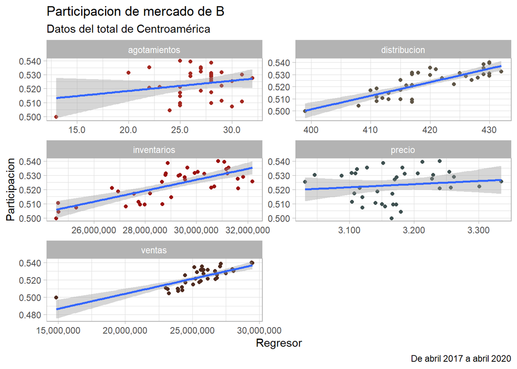

Pasemos a ver si puede existir algún problemas de colinealidad en las variables antes de ajustar un modelo de regresión. Distribución y participación presentan el índice más alto, pero no es mayor del 90%, por lo que no se esperaba que proporcionaran información redundante. Se tiene un determinante de la matriz diseño bastante cercano a cero, sin embargo, no se diagnostica que el problema de colinealidad exista.

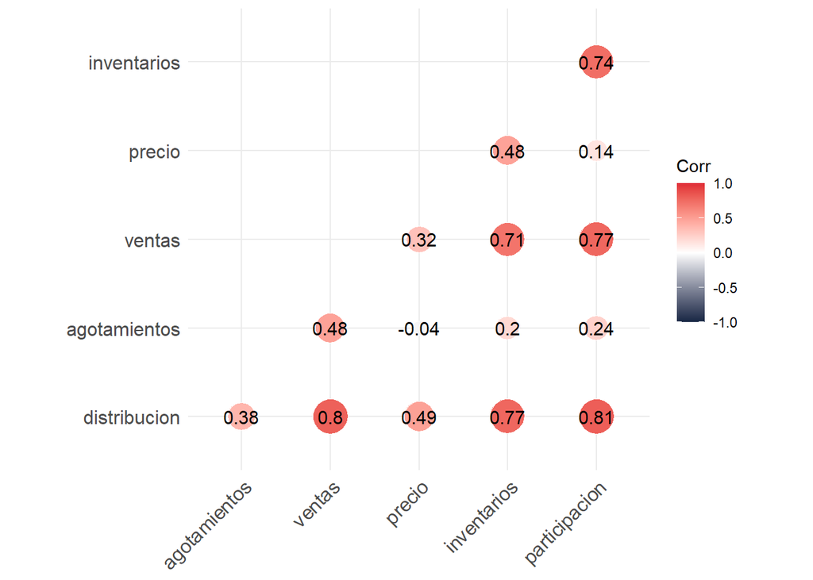

```
## Determinante:  0.009896291
```

Para finalizar el exploratorio, veamos cómo han evolucionado nuestras variables a lo largo de los tres años que comprenden nuestros datos.

Podemos ver que las ventas han tenido una tendencia lenta, pero consistente a la baja que podemos relaconar con el comportamiento de la participación, los inventarios y los puntos de distribución. Tanto inventarios como distribución empiezan a caer progresivamente desde la primera mitad del 2018. Existe un comportamiento similar en la participación de mercado, que presenta una caída y un valle en la primera mitad del 2019 seguido de una recuperación y fluctuaciones de menor tamaño. A principios del 2019 también vemos una caída en el precio del producto que después se recupera y estabiliza. Antes del 2019 el precio está reduciéndose durante más de un año.

A principios del 2020 hay una baja en casi todas las variables. Ejemplificando con ventas, se obserba un pequeño pico antes de la caída abrupta. Esto puede corresponder a los eventos de compras de pánico y posterior cuarentena. El comportamiento de pico y posterior baja no es muy marcado porque cada país en Centroamérica adoptó con diferente severidad distintas medidas para llevar a cabo o no el confinamiento.

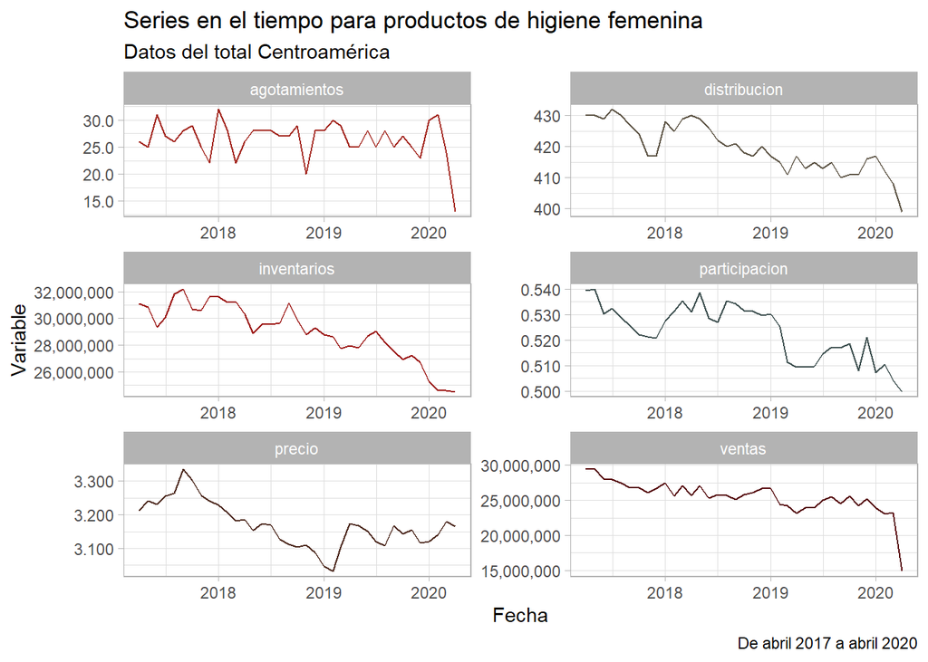

### Modelo de regresión lineal

Para ajustar el modelo se separó del total de los datos, una base de entrenamiento con observaciones hasta octubre 2019 y a partir de esa, se creo una base transformada con el objetivo de que los regresores obtenidos puedan ser comparados:

```r
base_est_CAM <- base_ent[base_ent$pais == "CAM",] %>%
  mutate_at(vars(distribucion:participacion), ~log(.))
```

Se llegó a la conclusión de que el modelo usaría las variables de inventarios, distribución, ventas y precio para explicar a la participación de mercado:

```r
mod_red_CAM <- "participacion ~   inventarios+
                                  distribucion +
                                  ventas +
                                  precio"

# Ajustamos el modelo

mod_CAM <- lm(mod_red_CAM, data = base_est_CAM)
```

Los residuales están muy cercanos al cero.

Podemos ver por los coeficientes que precio y distribución son los parámetros que más impactan sobre la participación de mercado. El producto de B tiene cierta inelasticidad en Centro América, sin embargo, recordemos que históricamente no se han manejado grandes variaciones en los niveles de precios.

```r
mod_CAM %>%
  summary()
```

```
##
## Call:
## lm(formula = mod_red_CAM, data = base_est_CAM)
##
## Residuals:
##        Min         1Q     Median         3Q        Max
## -0.0114299 -0.0046607 -0.0009226  0.0058218  0.0151660
##
## Coefficients:
##              Estimate Std. Error t value Pr(>|t|)
## (Intercept)  -7.47479    0.65669 -11.382 1.34e-11 ***
## inventarios   0.08705    0.04470   1.947 0.062360 .
## distribucion  0.57148    0.14766   3.870 0.000655 ***
## ventas        0.14035    0.03652   3.843 0.000703 ***
## precio       -0.44677    0.08029  -5.564 7.63e-06 ***
## ---
## Signif. codes:  0 '***' 0.001 '**' 0.01 '*' 0.05 '.' 0.1 ' ' 1
##
## Residual standard error: 0.007598 on 26 degrees of freedom
## Multiple R-squared:   0.83,  Adjusted R-squared:  0.8039
## F-statistic: 31.74 on 4 and 26 DF,  p-value: 1.167e-09
```

```r
mod_CAM %>%
  anova()
```

```
## Analysis of Variance Table
##
## Response: participacion
##              Df     Sum Sq    Mean Sq F value    Pr(>F)
## inventarios   1 0.00271117 0.00271117  46.967 2.830e-07 ***
## distribucion  1 0.00205664 0.00205664  35.628 2.668e-06 ***
## ventas        1 0.00077334 0.00077334  13.397  0.001127 **
## precio        1 0.00178725 0.00178725  30.961 7.631e-06 ***
## Residuals    26 0.00150087 0.00005773
## ---
## Signif. codes:  0 '***' 0.001 '**' 0.01 '*' 0.05 '.' 0.1 ' ' 1
```

Vemos que el modelo cumple con los supuestos de homocedasticidad y normalidad, pero el valor- p para la prueba de independencia en los errores es muy pequeño.

```r
# Normalidad
shapiro.test(mod_CAM$residuals)
```

```
##
##  Shapiro-Wilk normality test
##
## data:  mod_CAM$residuals
## W = 0.97294, p-value = 0.6032
```

```r
# Homocedasticidad
bptest(mod_CAM)
```

```
##
##  studentized Breusch-Pagan test
##
## data:  mod_CAM
## BP = 4.275, df = 4, p-value = 0.3701
```

```r
# Independencia
dwtest(mod_CAM)
```

```
##
##  Durbin-Watson test
##
## data:  mod_CAM
## DW = 1.3797, p-value = 0.007589
## alternative hypothesis: true autocorrelation is greater than 0
```

Al ver cómo se ve la correlación de nuestros residuales, no notamos valores que se salgan de la banda, por lo que podemos fijar un nivel de significancia menor al 10%.

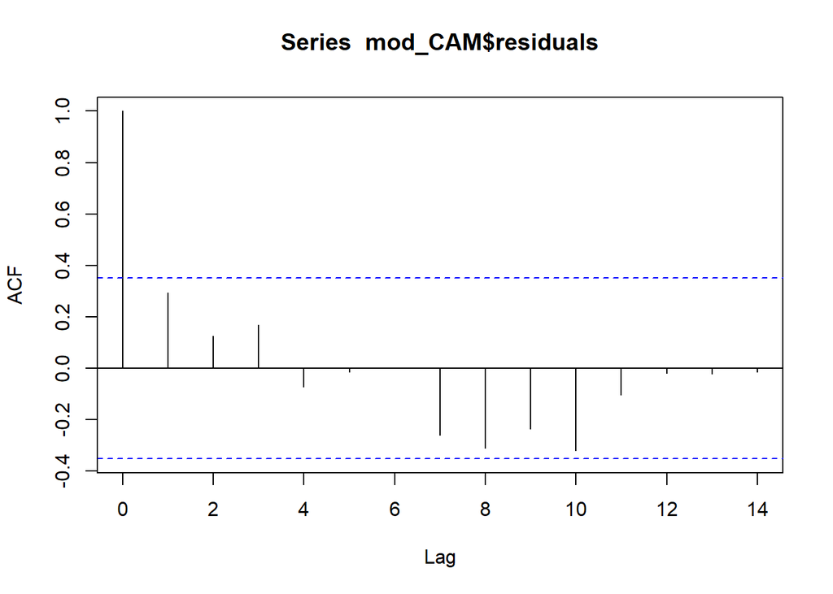

```r
acf(mod_CAM$residuals)
```

### Desempeño del modelo

Finalmente, veamos el desempeño del modelo propuesto y su bondad de ajuste.

Para ello lo primero será definiR la base de datos de prueba para la región de Centroamérica, que tiene datos de noviembre del 2019 a abril del 2020:

```r
base_prueba_trans_CAM <- base_prueba[base_prueba$pais == "CAM",] %>%
  mutate_at(vars(distribucion:participacion), ~log(.))
```

Para poder llevar a cabo la comparación de las predicciones del modelo con los datos estimados debe deshacerse la transformación de la variable respuesta y de la estimación:

```r
estim_prueba_CAM <- base_prueba_trans_CAM %>%
  cbind(est_log = predict(object = mod_CAM, base_prueba_trans_CAM)) %>%
  mutate(estimacion = exp(est_log), participacion = exp(participacion))
```

Creamos la base de datos para llevar a cabo la comparación:

```r
testing_CAM <- estim_prueba_CAM %>%
  select(fecha, participacion, estimacion)

testing_CAM
```

```
##        fecha participacion estimacion
## 1 2019-11-01     0.5080191  0.5107374
## 2 2019-12-01     0.5211156  0.5191408
## 3 2020-01-01     0.5072475  0.5133616
## 4 2020-02-01     0.5106277  0.5043215
## 5 2020-03-01     0.5043990  0.4994850
## 6 2020-04-01     0.4998149  0.4638779
```

```r
cor(testing_CAM$participacion, testing_CAM$estimacion)^2
```

```
## [1] 0.5850737
```

```r
testing_CAM %>%
  mutate(error = ((participacion-estimacion)/participacion)^2) %>%
  select(error) %>%
  summary()
```

```
##      error
##  Min.   :1.436e-05
##  1st Qu.:4.520e-05
##  Median :1.201e-04
##  Mean   :9.342e-04
##  3rd Qu.:1.507e-04
##  Max.   :5.170e-03
```

Finalmente podemos observar gráficamente el desempeño del modelo:

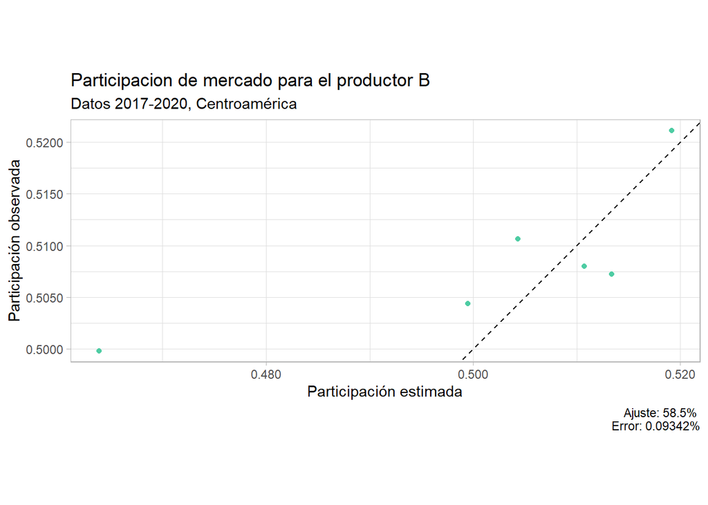

## Propuesta para Costa Rica

### Exploratorio

Para el caso de Cosa Rica vemos que la relación positiva entre precio y ventas es bastante fuerte (0.67) . Sin embargo los rangos de precio manejados en este país por el productor B tan sólo varían un 18% entre el mínimo precio y el máximo, por lo que no se tiene evidencia contundente para pensar que las costariqueñas incrementarán su consumo ante incrementos en el precio.

Podemos observar que la participación en el mercado guarda una relación negativa con las ventas. La participación de mercado es definida como el procentaje de ventas de un producto o servicio que tiene un agente respecto al total de las ventas en el mercado que participa.

La relación negativa entre participación y ventas diría que a mayor participación, menores ventas. Lo que puede estar sucediendo para obtener esta relación es que las ventas de todo el mercado se están reduciendo, de forma que, aunque aumente la participación del productor B, el mercado es más pequeño, por lo que sus ventas lo son también.

También llama la atención que la participación de mercado guarda una relación negativa con todas las variables, lo que de igual forma puede deberse a una reducción del mercado total. La participación varía poco, al rededor de un 11% entre su mínimo y máximo y es mayor al 55% en su nivel más bajo.

```
##      fecha                pais            distribucion    agotamientos
##  Min.   :2017-04-01   Length:37          Min.   :73.00   Min.   :2.000
##  1st Qu.:2018-01-01   Class :character   1st Qu.:76.00   1st Qu.:3.000
##  Median :2018-10-01   Mode  :character   Median :77.00   Median :4.000
##  Mean   :2018-10-01                      Mean   :77.24   Mean   :3.973
##  3rd Qu.:2019-07-01                      3rd Qu.:78.00   3rd Qu.:5.000
##  Max.   :2020-04-01                      Max.   :80.00   Max.   :8.000
##
##      ventas            precio       inventarios      participacion
##  Min.   :2000300   Min.   :3.798   Min.   :1794100   Min.   :0.5507
##  1st Qu.:3000800   1st Qu.:4.026   1st Qu.:2123500   1st Qu.:0.5743
##  Median :3272700   Median :4.138   Median :2516600   Median :0.5915
##  Mean   :3239173   Mean   :4.192   Mean   :2420200   Mean   :0.5876
##  3rd Qu.:3499000   3rd Qu.:4.375   3rd Qu.:2715700   3rd Qu.:0.5992
##  Max.   :3797400   Max.   :4.494   Max.   :2929700   Max.   :0.6148
##
##       mes
##  4      : 4
##  1      : 3
##  2      : 3
##  3      : 3
##  5      : 3
##  6      : 3
##  (Other):18
```

```
##               distribucion agotamientos     ventas      precio inventarios
## distribucion    1.00000000   0.05020298  0.7560630  0.56778201   0.6955138
## agotamientos    0.05020298   1.00000000 -0.1416440 -0.06040801  -0.2671137
## ventas          0.75606295  -0.14164398  1.0000000  0.67298566   0.8476757
## precio          0.56778201  -0.06040801  0.6729857  1.00000000   0.8022003
## inventarios     0.69551378  -0.26711372  0.8476757  0.80220025   1.0000000
## participacion  -0.26859454  -0.20892120 -0.2794926 -0.65516043  -0.3875616
##               participacion
## distribucion     -0.2685945
## agotamientos     -0.2089212
## ventas           -0.2794926
## precio           -0.6551604
## inventarios      -0.3875616
## participacion     1.0000000
```

De los diagramas de dispersión podemos observar la relación negativa de las variables con la participación de mercado. La pendiente más marcada corresponde a la relación con precios. Esta variable se mueve en un rango pequeño, pero su variación es la que repercute con un mayor efecto reductor en la participación de mercado.

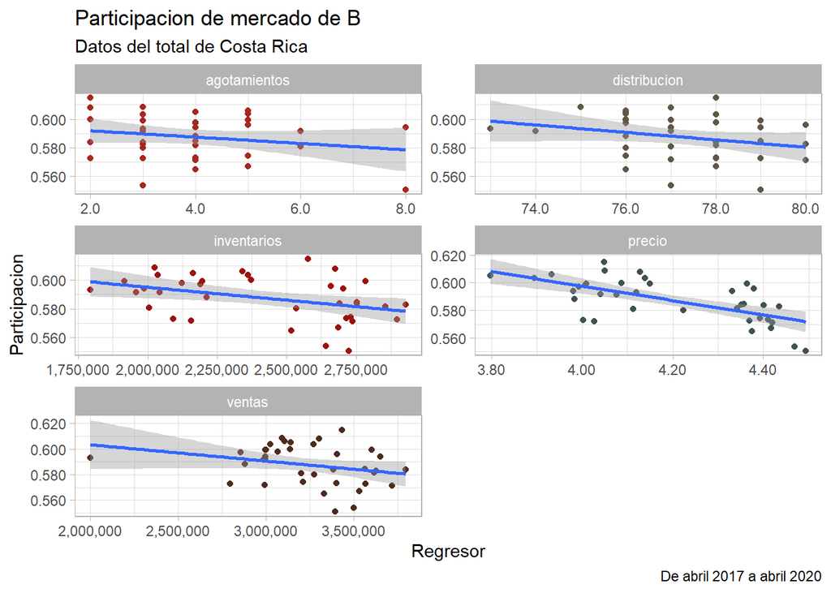

Evaluemos ahora si podemos enfrentarnos a un problema de colinealidad. La mayor relación observada es entre inventarios y ventas (0.85). El determinante obtenido es pequeño, sin embargo, no se concluye que la información presentada entre inventarios y ventas sea redundante.

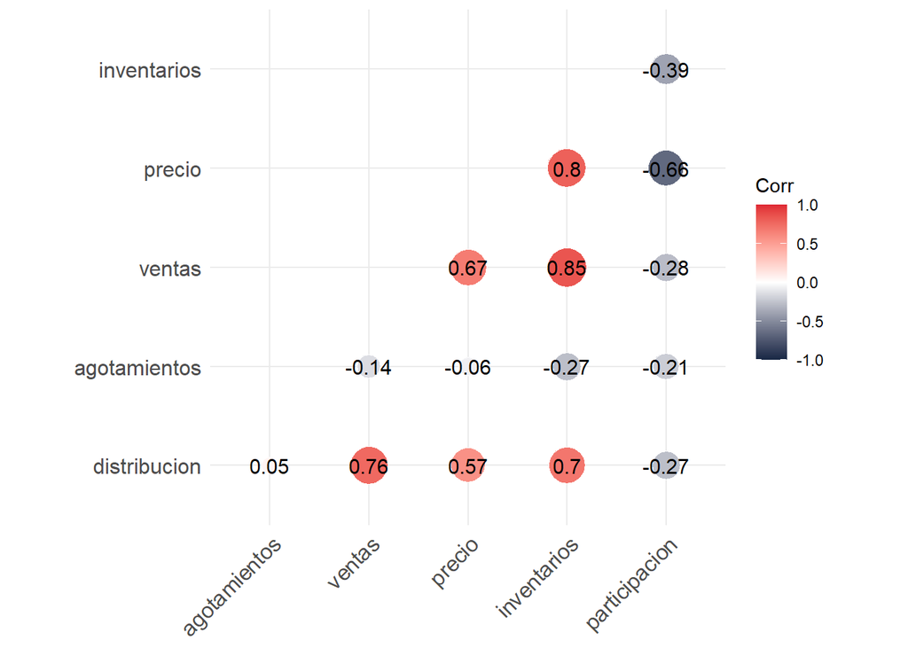

```
## Determinante:  0.01495675
```

Ahora pasemos a ver las series de tiempo de las variables para Costa Rica.

Podemos encontrar un pico en las ventas a principios del 2020 y un posterior desplome de estas, junto a una subida de precios y posterior estabilización en el mismo periodo. Podemos pensar que estos comportamientos guardan relación con la actual pandemia, pues, según la BBC, Costa Rica es una de los países en Centroamérica que aplicó medidas de confinamiento restrictivas, teniendo aún en vigor la cuarentena que empezaron el 15 de marzo.

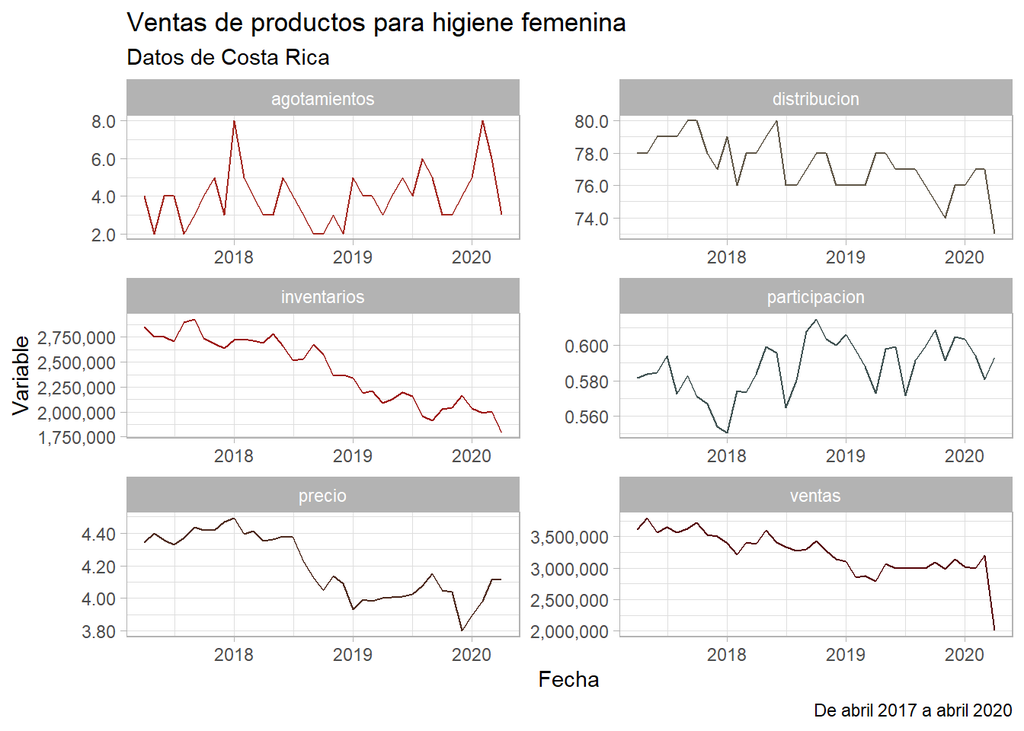

### Modelo de regresión lineal

Para ajustar el modelo se separó del total de los datos, una base de entrenamiento con observaciones hasta octubre 2019 y a partir de esa, se creo una base transformada con el objetivo de que los regresores obtenidos puedan ser comparados:

```r
base_est_CR <- base_ent[base_ent$pais == "CR",] %>%
  mutate_at(vars(distribucion:participacion), ~log(.))
```

En el ajuste del modelo para Costa Rica se tomaron en cuenta como variables regresoras: ventas, precio, inventarios, distribución y mes. Además se consideraró la interacción entre ventas e inventarios y distribución e inventarios.

```r
mod_red_CR <- "participacion ~  ventas + precio + inventarios +
    distribucion + mes + ventas:inventarios + inventarios:distribucion"

# Ajustamos el modelo

mod_CR <- lm(mod_red_CR, data = base_est_CR)
```

Al observar el resumen del modelo tenemos un intercepto no significativo. Precio, ventas, distribución y algunos meses son variables regresoras significativas. Inventarios es significativa sólo por sus interacciones. Con el análisis de varianza, vemos que inventarios y distribucion aportan poco a la suma de cuadrados.

Además tenemos un coeficiente de determinación cercano al 78% y residuales con media en el cero y poca distancia entre mínimo y máximo. Costa Rica fue un país difícil para encontrar un modelo de regresión lineal. Una de las mejores opciones para este modelo era usar sólo dos variables regresoras: ventas y precio. Sin embargo, el coeficiente de determinación obtenido de esta forma era menor al 60%, por lo que se decidió por utilizar interacciones para mejorar el modelo en cuanto fuera posible.

```r
mod_CR %>%
  summary()
```

```
##
## Call:
## lm(formula = mod_red_CR, data = base_est_CR)
##
## Residuals:
##        Min         1Q     Median         3Q        Max
## -0.0188931 -0.0063474 -0.0004768  0.0055479  0.0183346
##
## Coefficients:
##                            Estimate Std. Error t value Pr(>|t|)
## (Intercept)              -1.928e+02  1.356e+02  -1.421  0.17873
## ventas                    3.965e+01  9.409e+00   4.214  0.00101 **
## precio                   -9.245e-01  1.217e-01  -7.598 3.91e-06 ***
## inventarios               1.256e+01  9.133e+00   1.375  0.19227
## distribucion             -9.157e+01  3.015e+01  -3.037  0.00953 **
## mes2                      6.294e-02  1.671e-02   3.767  0.00235 **
## mes3                      3.204e-02  1.412e-02   2.270  0.04090 *
## mes4                      4.464e-02  1.454e-02   3.070  0.00894 **
## mes5                      3.163e-02  1.509e-02   2.096  0.05624 .
## mes6                      3.014e-02  1.248e-02   2.414  0.03123 *
## mes7                      7.203e-03  1.302e-02   0.553  0.58953
## mes8                      2.252e-02  1.301e-02   1.731  0.10713
## mes9                      4.232e-02  1.278e-02   3.312  0.00562 **
## mes10                    -1.297e-03  1.461e-02  -0.089  0.93061
## mes11                     1.157e-02  1.466e-02   0.789  0.44441
## mes12                     1.370e-02  1.411e-02   0.971  0.34912
## ventas:inventarios       -2.661e+00  6.370e-01  -4.177  0.00108 **
## inventarios:distribucion  6.244e+00  2.051e+00   3.045  0.00939 **
## ---
## Signif. codes:  0 '***' 0.001 '**' 0.01 '*' 0.05 '.' 0.1 ' ' 1
##
## Residual standard error: 0.01305 on 13 degrees of freedom
## Multiple R-squared:  0.905,  Adjusted R-squared:  0.7808
## F-statistic: 7.286 on 17 and 13 DF,  p-value: 0.000396
```

```r
mod_CR %>%
  anova()
```

```
## Analysis of Variance Table
##
## Response: participacion
##                          Df    Sum Sq   Mean Sq F value    Pr(>F)
## ventas                    1 0.0015807 0.0015807  9.2853  0.009351 **
## precio                    1 0.0122254 0.0122254 71.8150 1.184e-06 ***
## inventarios               1 0.0000624 0.0000624  0.3663  0.555449
## distribucion              1 0.0000080 0.0000080  0.0471  0.831561
## mes                      11 0.0040425 0.0003675  2.1588  0.094207 .
## ventas:inventarios        1 0.0015873 0.0015873  9.3242  0.009237 **
## inventarios:distribucion  1 0.0015784 0.0015784  9.2718  0.009390 **
## Residuals                13 0.0022130 0.0001702
## ---
## Signif. codes:  0 '***' 0.001 '**' 0.01 '*' 0.05 '.' 0.1 ' ' 1
```

El modelo para Costa Rica cumple los supuestos de normalidad y homocedasticidad en los residuales para un nivel de significancia mayor al 10%.

```r
shapiro.test(mod_CR$residuals) # Normalidad
```

```
##
##  Shapiro-Wilk normality test
##
## data:  mod_CR$residuals
## W = 0.98258, p-value = 0.8798
```

```r
bptest(mod_CR) # Homocedasticidad
```

```
##
##  studentized Breusch-Pagan test
##
## data:  mod_CR
## BP = 23.458, df = 17, p-value = 0.1349
```

```r
dwtest(mod_CR) # Independencia
```

```
##
##  Durbin-Watson test
##
## data:  mod_CR
## DW = 2.2667, p-value = 0.4171
## alternative hypothesis: true autocorrelation is greater than 0
```

### Desempeño del modelo

Finalmente, veamos el desempeño del modelo propuesto y su bondad de ajuste.

Para ello lo primero será definir la base de datos de prueba para la región de Costa Rica, que tiene datos de noviembre del 2019 a abril del 2020:

```r
base_prueba_trans_CR <- base_prueba[base_prueba$pais == "CR",] %>%
  mutate_at(vars(distribucion:participacion), ~log(.))
```

Para poder llevar a cabo la comparación de las predicciones del modelo con los datos estimados debe deshacerse la transformación de la variable respuesta y de la estimación:

```r
estim_prueba_CR <- base_prueba_trans_CR %>%
  cbind(est_log = predict(object = mod_CR, base_prueba_trans_CR)) %>%
  mutate(estimacion = exp(est_log), participacion = exp(participacion))
```

Creamos la base de datos para llevar a cabo la comparación:

```r
testing_CR <- estim_prueba_CR %>%
  select(fecha, participacion, estimacion)

testing_CR
```

```
##        fecha participacion estimacion
## 1 2019-11-01     0.5916899  0.6020650
## 2 2019-12-01     0.6050532  0.6485070
## 3 2020-01-01     0.6034651  0.6094350
## 4 2020-02-01     0.5940963  0.6232977
## 5 2020-03-01     0.5808032  0.6278365
## 6 2020-04-01     0.5931912  0.3778334
```

```r
cor(testing_CR$participacion, testing_CR$estimacion)^2
```

```
## [1] 0.01334766
```

```r
testing_CR %>%
  mutate(error = ((participacion-estimacion)/participacion)^2) %>%
  select(error) %>%
  summary()
```

```
##      error
##  Min.   :9.786e-05
##  1st Qu.:8.346e-04
##  Median :3.787e-03
##  Mean   :2.439e-02
##  3rd Qu.:6.208e-03
##  Max.   :1.318e-01
```

Finalmente podemos observar gráficamente el desempeño del modelo:

[figure not shown]

## Propuesta para El Salvador

### Exploratorio

```
##      fecha                pais            distribucion    agotamientos
##  Min.   :2017-04-01   Length:37          Min.   :52.00   Min.   :2.000
##  1st Qu.:2018-01-01   Class :character   1st Qu.:57.00   1st Qu.:4.000
##  Median :2018-10-01   Mode  :character   Median :58.00   Median :5.000
##  Mean   :2018-10-01                      Mean   :57.54   Mean   :4.649
##  3rd Qu.:2019-07-01                      3rd Qu.:59.00   3rd Qu.:5.000
##  Max.   :2020-04-01                      Max.   :61.00   Max.   :8.000
##
##      ventas            precio       inventarios      participacion
##  Min.   :1381500   Min.   :3.362   Min.   :2383300   Min.   :0.2802
##  1st Qu.:2285300   1st Qu.:3.420   1st Qu.:2731600   1st Qu.:0.3259
##  Median :2419700   Median :3.440   Median :3126600   Median :0.3470
##  Mean   :2530686   Mean   :3.439   Mean   :3048241   Mean   :0.3488
##  3rd Qu.:2766500   3rd Qu.:3.462   3rd Qu.:3349100   3rd Qu.:0.3696
##  Max.   :3347600   Max.   :3.504   Max.   :3514700   Max.   :0.3990
##
##       mes
##  4      : 4
##  1      : 3
##  2      : 3
##  3      : 3
##  5      : 3
##  6      : 3
##  (Other):18
```

```
##               distribucion agotamientos    ventas      precio inventarios
## distribucion     1.0000000   0.27360634 0.5493547  0.24144034   0.7526093
## agotamientos     0.2736063   1.00000000 0.2480871 -0.01889726   0.2257010
## ventas           0.5493547   0.24808710 1.0000000  0.19199449   0.5933060
## precio           0.2414403  -0.01889726 0.1919945  1.00000000   0.2299866
## inventarios      0.7526093   0.22570103 0.5933060  0.22998655   1.0000000
## participacion    0.5599559   0.20751365 0.9492381  0.29361785   0.5991789
##               participacion
## distribucion      0.5599559
## agotamientos      0.2075136
## ventas            0.9492381
## precio            0.2936179
## inventarios       0.5991789
## participacion     1.0000000
```

Podemos pensar que para mantener la participación de mercado y las ventas en El Salvador, es más importante mantener inventarios altos en ciertos puntos de distribución que se han identificado que presentan una demanda mayor y es un sólo un poco menos importante, expandirse a nuevos puntos de distribución.